# COVID-19 logistic curve modeling by US state

Single state example

2021-09-10

# Background

Although it can often be misleading to try to predict the trend of an epidemic (from limited and flawed data) during its early-to-mid stages, it is often important to try to predict some features during the outbreak, rather than to wait until retrospective data is available. When is the right time? For relatively closed systems, the cumulative case curve will always be S-shaped and well-described by a logistic-type model - with the essential factors being the inflection time ($t_m$) and estimated maximum caseload. As long as the available data include this inflection point and a time interval shortly after, the curve fitting (and estimated future case number) will be reasonably accurate. [1]

First, load the tidyverse library (install if needed):

```r
#install.packages("tidyverse")
library(tidyverse)
library(ggplot2)
library(ggpubr)
theme_set(theme_pubr())
library(zoo)
library(ggthemes)
```

## Import and format

```r
mydata <- read.csv(url("https://raw.githubusercontent.com/CSSEGISandData/COVID-19/master/csse_covid_19_data/csse_covid_19_time_series/time_series_covid19_confirmed_US.csv"), na.strings = c("", "NA"))
deaths <- read.csv(url("https://raw.githubusercontent.com/CSSEGISandData/COVID-19/master/csse_covid_19_data/csse_covid_19_time_series/time_series_covid19_deaths_US.csv"), na.strings = c("", "NA"))
```

```r
State <- "Utah"
k = 20 #future days
CASES <- mydata %>%
  filter(Province_State ==State) %>%
  select(starts_with("X"))
```

## State and forecast days

For example, let’s use `Utah`. And for any forecasts, we’ll set `20` days. It’s easy to change state, but note in the final figure the spacing of text might be off, so you’ll need to customize to not smoosh text.

Now some data wrangling to get dates, restrict to where positive cases, and take a peek at the temp data.

```r
Y<- colSums(CASES)
n <- as.numeric(length(Y))

temp1 <- data.frame(y = Y, x = seq(1:n))
temp1$date<-row.names(temp1)

temp <- temp1 %>% filter(y > 0)
(date1<-substr(temp[1,]$date, 2, 8))
```

```
## [1] "3.7.20"
```

```r
(date<-substr(temp[temp$x==max(temp$x),]$date, 2, 8))
```

```
## [1] "9.9.21"
```

```r
(Max <- temp[temp$x==max(temp$x),]$y)
```

```
## [1] 477790
```

```r
head(temp)
```

```
##          y  x     date
## X3.7.20  1 46  X3.7.20
## X3.8.20  1 47  X3.8.20
## X3.9.20  1 48  X3.9.20
## X3.10.20 2 49 X3.10.20
## X3.11.20 3 50 X3.11.20
## X3.12.20 3 51 X3.12.20
```

Some more data wrangling and calculations to get percent changes.

```r
last_obs <- max(temp$x)
next_last_obs <- last_obs - 1
seven_days_ago <- last_obs - 7
new_cases <- temp[ temp$x ==last_obs , 1] - temp[ temp$x ==next_last_obs , 1]

one_day_percent <- (temp[ temp$x ==last_obs , 1] - temp[ temp$x ==next_last_obs , 1])/temp[ temp$x ==next_last_obs, 1] *100

seven_days_percent <- (temp[ temp$x ==last_obs , 1] - temp[ temp$x ==seven_days_ago , 1])/temp[ temp$x ==seven_days_ago, 1] *100
```

## Logistic curve

Now calculate the logistic curve.

### Updated to double logistic, but harvesting model parameters broken/wonky

```r
#Z <- nls(y ~ SSlogis(x, Asym, xmid, scal), temp); ZZ<-summary(Z)
# State <- "Utah"
# CASES <- mydata %>%
#   filter(Province_State ==State) %>%
#   select(starts_with("X"))
#
#
# Y<- colSums(CASES)
# n <- as.numeric(length(Y))
#
# temp1 <- data.frame(y = Y, x = seq(1:n))
# temp1$date<-row.names(temp1)
#
# temp <- temp1 %>% filter(y > 0)
y <- temp$y
x <- temp$x
Z <- nls(y ~  (( k1 / (1 + exp( (-log(81)/a1) * (x - b1)))) +
                               ( k2 / (1 + exp( (-log(81)/a2) * (x - b2))))),
                      start=c(a1=87,k1=38000,b1=150,
                              a2=104,k2=400000,b2=300))
ZZ<-summary(Z)
peak <- ZZ$parameters[1]
midpoint <- temp %>%
  filter(x == round(ZZ$parameters[2])) %>%
  mutate(date = str_sub(date, 2, 8)) %>%
  select(date)
```

```r
round(peak) # estimated asymptote
```

```
## [1] 60
```

**Inflection date**

```r
midpoint # date of inflection point
```

```
## [1] date
## <0 rows> (or 0-length row.names)
```

**AIC** *(smaller is better)*

```r
AIC(Z) # AIC = -2LL + 2k
```

```
## [1] 11900.93
```

```r
BIC(Z)
```

```
## [1] 11931.13
```

# Plot

```r
 # pdf("curve.pdf", width = 12, height = 12)
 # png(file = "curve.png", width = 1080, height = 900, units = "px", pointsize = 14)
par(family="serif")
plot(temp$x, temp$y, ylab = "COVID SARS-2 Confirmed Cases", xlab="", xlim =c(min(temp$x),n+k),
     ylim=c(0, max(temp$y) + 0.25*max(temp$y)), type="l", col="navy", lwd=3,
     axes=F,
     main = paste("COVID-19 cases in", State, " (updated", date , ")"),
     sub = "Using 2019 Novel Coronavirus COVID-19 (2019-nCoV)
     Data Repository by Johns Hopkins CSSE")

axis(2)
axis(1, at=c(temp[1,2], max(temp$x) ), lab=c(date1, date))

lines(seq(1:n), predict(Z, list(x = seq(1:n))), lwd=2, col='blue', lty=3)
abline( h = max(temp$y), lty=3)
#abline( h = ZZ$parameters[1], lty=3)
#abline(v=temp[temp$date == "X8.18.20",]$x, lty=2, col="red")
text(max(temp$x)-120, max(temp$y) -24000, paste("Daily new cases = ", new_cases ))
text(max(temp$x)-120, max(temp$y)-16000, paste("Daily percent increase = ", round(one_day_percent,1), "%" ))
text(max(temp$x)-120, max(temp$y)-8000, paste("Seven-day percent increase = ", round(seven_days_percent,1), "%" ))

#text(max(temp$x)-80, ZZ$parameters[1]-2000, paste("Estimated case asymptote = ", round(ZZ$parameters[1])), col="grey")
#text(n,  1000, paste("model AIC = ", round(AIC(Z),2), "\n (smaller is better)"),col="grey")

Z10 <- round(predict(Z, list(x = seq(n+1,n+k))))

#k-day forecast
Z10[1:k]
```

```
##  [1] 424178 424189 424200 424211 424221 424231 424241 424250 424259 424268
## [11] 424277 424286 424294 424303 424311 424318 424326 424333 424341 424348
```

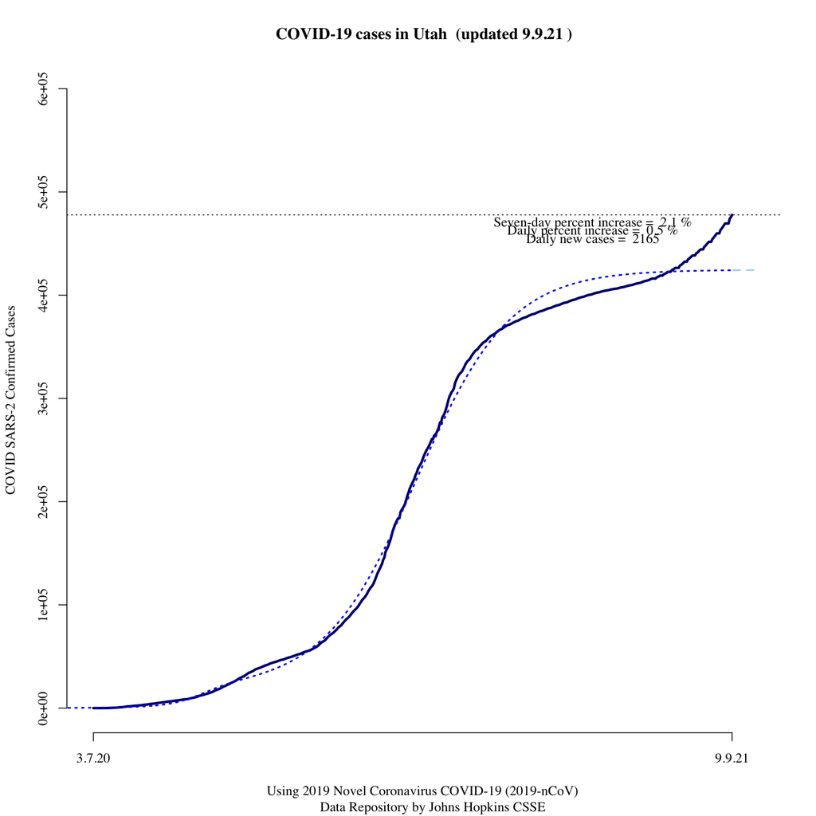

```r
lines(seq(n+1,n+k), Z10[1:k], col="lightblue", lwd=2, lty=2)
```

```r
 # dev.off()
```

## References

[1] Hsieh YH, Lee JY, Chang HL. SARS epidemiology modeling. *Emerg Infect Dis.* 2004;10(6):1165-1168. doi:10.3201/eid1006.031023

# Daily case increase from COVID tracker

```r
mydata0 <-read.csv(url("https://raw.githubusercontent.com/CivilServiceUSA/us-governors/master/us-governors/data/us-governors.csv"), na.strings = c("", "NA")) %>%
        dplyr::select(state_code, state_name, party) %>%
        rename(state = state_code)
mydata2 <-read.csv(url("https://covidtracking.com/api/v1/states/daily.csv"), na.strings = c("", "NA"))

mydf <- merge(mydata0, mydata2 , by="state")
        mydf$Date <- as.Date(as.character(mydf$date), "%Y %m %d")
```

```r
State  = "UT"
St <- mydata2 %>%
        filter(state==State) %>%
        filter(positiveIncrease > 0)
St$Date <- as.Date(as.character(St$date), "%Y %m %d")
theme_set(theme_few(base_size = 14, base_family = "serif"))
```

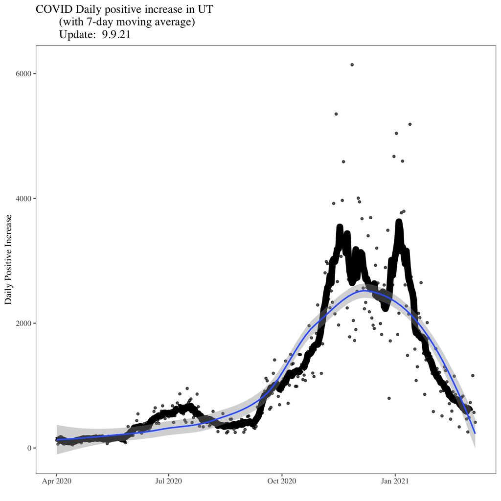

```r
min <- as.Date("2020-4-1")
max <- NA

r<- ggplot(
        St,
        aes(x = Date , y = positiveIncrease)) +
        geom_point(show.legend = FALSE, alpha = 0.7) +
        #facet_wrap(mydf$state_name, scales = "free") +
        geom_line(aes(y=rollmean(positiveIncrease, 7, na.pad=TRUE), size=1.5))+
        geom_smooth()  + #ylim(0, 1500) +
        #geom_point(aes(x = as.Date("2020-09-25"), y=1411), colour="red", size=1.5) +
        scale_color_manual(values = c("#00AFBB", "#FC4E07")) +
        labs(x = "", y = "Daily Positive Increase", title = paste("COVID Daily positive increase in", State, "
        (with 7-day moving average)", "
        Update: ", date)) + scale_x_date(limits = c(min, max)) +
        theme(legend.position = "none")

  # r <- r + geom_vline(xintercept=St[St$Date=="2020-08-05",55],
  #                linetype=4, colour="red")
  #+ annotate("text", x = as.Date("2020-08-5"), y=5, label = "Inflection (2)")

# pdf("UT.pdf", width = 12, height = 10)
# png(file = "UT.png", width = 1080, height = 900, units = "px", pointsize = 14)
r
```

```r
# dev.off()
```

```r
library(dygraphs)
library(xts)

cases.ts <- xts(St$positiveIncrease, order.by=as.POSIXct(St$Date))

dygraph(cases.ts, main = paste("Daily increase COVID cases in", State)) %>%
  dyRoller(rollPeriod = 5) %>%
  dySeries("V1", strokeWidth = 3, label = "5-day rolling daily case increase") %>%
  dyShading(from = "2021-01-01", to = Sys.Date(), color = "#FFE6E6") %>%
  dyRangeSelector()
```

[interactive chart not shown]

# Experimental: Bi-logistic growth

$$N(t) = \sum_{i=1}^{m} \frac{k_i}{1+ e^{(-ln(81)/\Delta t_{mi})(t-t_{mi})}}$$

In the two-wave or two-pulse logistic case, this simplifies to:

$$N(t) = \frac{k_1}{1+ e^{(-ln(81)/\Delta t_{m1})(t-t_{m1})}}+\frac{k_2}{1+ e^{(-ln(81)/\Delta t_{m2})(t-t_{m2})}}$$

Resetting to Utah as model needs good starting values and not obvious how to pull them out:

```r
State <- "Utah"
CASES <- mydata %>%
  filter(Province_State ==State) %>%
  select(starts_with("X"))


Y<- colSums(CASES)
n <- as.numeric(length(Y))

temp1 <- data.frame(y = Y, x = seq(1:n))
temp1$date<-row.names(temp1)

temp <- temp1 %>% filter(y > 0)
```

```r
y <- temp$y
x <- temp$x

bilogistic <- nls(y ~  (( k1 / (1 + exp( (-log(81)/a1) * (x - b1)))) +
                               ( k2 / (1 + exp( (-log(81)/a2) * (x - b2))))),
                      start=c(a1=87,k1=38000,b1=150,
                              a2=104,k2=400000,b2=300))


bilogistic
```

```
## Nonlinear regression model
##   model: y ~ ((k1/(1 + exp((-log(81)/a1) * (x - b1)))) + (k2/(1 + exp((-log(81)/a2) *     (x - b2)))))
##    data: parent.frame()
##        a1        k1        b1        a2        k2        b2
##     60.18  20052.87    139.62    176.31 404574.79    325.12
##  residual sum-of-squares: 7.273e+10
##
## Number of iterations to convergence: 18
## Achieved convergence tolerance: 8.826e-06
```

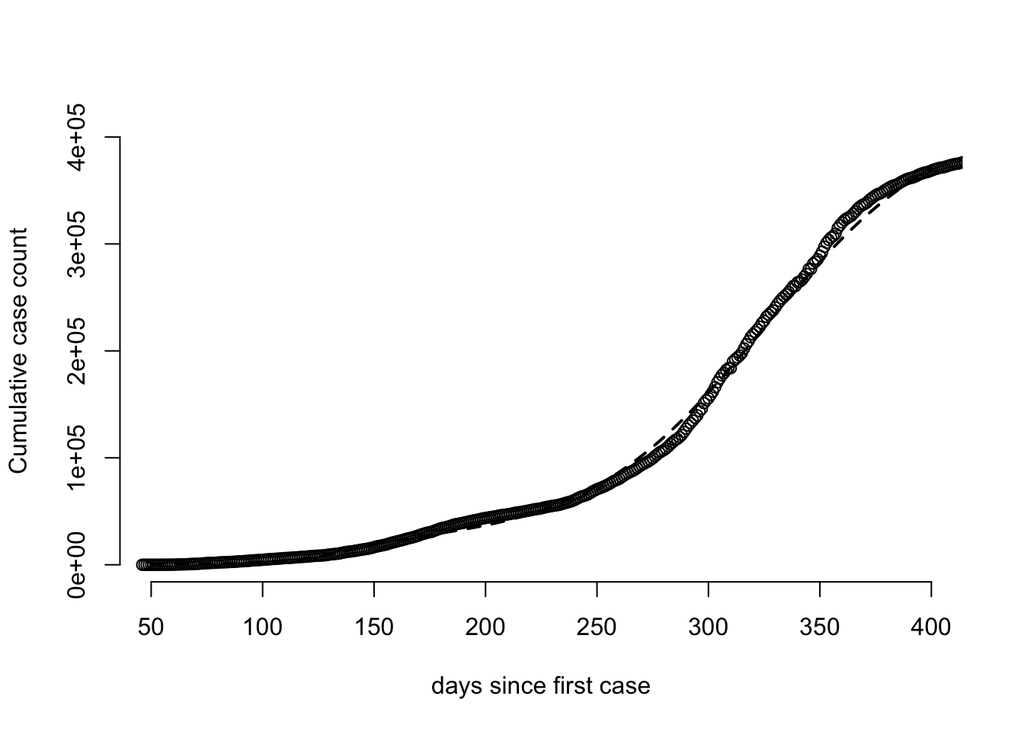

```r
plot(x,y, ylim=c(0,400000), xlim=c(50,400), ylab = "Cumulative case count", xlab = "days since first case", axes=F); axis(1); axis(2)
newx  <- seq(50,400)
lines(newx,predict(bilogistic,newdata=data.frame(x=newx)),lwd=2, lty=2)
```

```r
AIC(bilogistic)
```

```
## [1] 11900.93
```

```r
BIC(bilogistic)
```

```
## [1] 11931.13
```

# Other

https://logletlab.com

https://www.ncbi.nlm.nih.gov/pmc/articles/PMC7167569/